# Introdution

**Objectives** : In this pratical session, you will learn :

- how to clean single cells data and extract high quality cells
- identify sub-populations of cells

We will be using the R packages Seurat and apply it functionalities to subset of the data publilshied with Karaiskos et al (replicate3).

## Sources of inspiration

This course material is largely inspired by two great sources that we advise you to read/use in details:

- [sincellTE 2020](https://cloud.biologie.ens.fr/index.php/s/RXkNGwtR1MLf5mo) : MA Dillies, A. Rausell, M Deloger, N. Servant, M. Thomas-Chollier, A. Paquet, cours6_TP_EDA_Normalization_2020.html
- [Vignette Seurat](https://satijalab.org/seurat/archive/v3.2/pbmc3k_tutorial.html)

## Bibliography

Karaiskos et al.The Drosophila embryo at single-cell transcriptome resolution. Science13 Oct 2017 : 194-199

# Working with Seurat

## Load the library

Seurat is an R package designed for the analysis of single-cell RNA-seq data.

```r
library(Seurat)
```

## Import the data

Single-cell RNA-seq data are presented in a matrix, where each row represents a gene and each column represents a single cell with a raw count (UMI). We first load the text file then create a “Seurat object”, the data structure suitable to work with Seurat.

```r
raw_counts<-read.csv2(file="data/data_day1/GSM2494785_dge_mel_rep3.txt",sep="\t")
raw_counts[1:3,1:5]
```

```
##            GENE TCCCTAAAGTAN TTTAAGCTCTTN AGAGAGAATACA GCCCGTGGAGCA
## 1         128up            0            1            1            2
## 2 14-3-3epsilon          426          371          438          380
## 3    14-3-3zeta           64           54           58           58
```

```r
print(dim(raw_counts))
```

```
## [1] 17026  1586
```

To work with Seurat, you need to create a Seurat Object. Here, we create a Seurat object from our dataframe. We modify the table raw_counts to have the field “GENE” as the rownames.

```r
rownames(raw_counts) = raw_counts$GENE
raw_counts$GENE = NULL
```

```r
mydata <- CreateSeuratObject(raw_counts, min.cells = 2, min.features = 200)
mydata
```

```
## An object of class Seurat
## 12511 features across 1579 samples within 1 assay
## Active assay: RNA (12511 features, 0 variable features)
```

**Alternative:** if you have a directory produced by CellRanger, you create your Seurat object with the function *read10X*. This function takes as argument the name of the folder containing the output of CellRanger (matrix.mtx, genes.tsv, barcodes.tsv).

## Explore the Seurat data structure

A Seurat object is not the easiest structure to work with, but with a but of practice you will learn to appreciate its potentiality.

In Seurat, data are organised in different compartements (slots), which contains them-selves several compartements, which can them-selves contain sub compartments…

Each compartment can be used to store:

- data from multiple modalities, such as RNAseq, spatial transcriptomics, ATAC-seq… For our session today, we will only focus on scRNAseq data (slot “assays”, sub-slot “RNA”)
- general results regarding your data, e.g. the total number of UMI expressed (slot meta.data)
- resultst of analyses: PCA components or clustering results)

```r
slotNames(mydata)
```

```
##  [1] "assays"       "meta.data"    "active.assay" "active.ident" "graphs"
##  [6] "neighbors"    "reductions"   "images"       "project.name" "misc"
## [11] "version"      "commands"     "tools"
```

You navigate through this hierachie using ‘@’ and ‘$’ signs.

```r
slotNames(mydata@assays$RNA)
```

```
## [1] "counts"        "data"          "scale.data"    "key"
## [5] "assay.orig"    "var.features"  "meta.features" "misc"
```

In the slots associated RNA, you can store:

- *counts* : raw UMI (the data we imported)
- *data* : filtered/normalized counting matrix
- *scale.data* : normalize and scaled data (usually for PCA analyses)
- *var.features*: contains a list of genes genes that contribute strongly to cell-to-cell variation (see section on highly variable genes)

You can access the data directly with the function GetAssayData function.

```r
# mydata@assays$RNA@counts[1:3,1:5]
GetAssayData(mydata, slot="counts")[1:3,1:5]
```

```
## 3 x 5 sparse Matrix of class "dgCMatrix"
##               TCCCTAAAGTAN TTTAAGCTCTTN AGAGAGAATACA GCCCGTGGAGCA ACTAGACCAAGT
## 128up                    .            1            1            2            4
## 14-3-3epsilon          426          371          438          380          358
## 14-3-3zeta              64           54           58           58           35
```

In Seurat, data are stored as “dgCMatrix”, which is an efficient way o store an array with a lot of zero in a computer (sparse matrix).

# Basic single cell pipeline

The steps below encompass the standard pre-processing workflow for scRNA-seq data.

- Filter out *low quality* cells: undersequenced cells, debris (broken cells or floating pieces of RNA) and multiplets (several cells in one droplets)
- Normalize the UMI expression to reduce the sequencing biais (some cells are less sequenced than others).

## Remove “low quality cells”

The are a few metrics commonly used to filter out low quality cells :

- the number of unique genes detected in each cell
  - cells with low gene count : helps to remove empty droplets, debris and undersequenced cells.
  - cells with high gene count : these cells are more likely to be cell doublets or multiplets. The number of multiplets expected in your sample is directly correlated with the number of cells you loaded in 10X. The more cells you loaded, the higher the chance is to have 2 or more cells in one droplet.
- the total number of UMI detected within a cell
  - the total number of UMI and the number of genes are highly correlated. Looking at the scatter plot between these two variables helps you detect atypical cells.
- the percentage of reads that map to the mitochondrial genome : low-quality / dying cells often exhibit extensive mitochondrial contamination

Seurat allows you to easily explore QC (quality control) metrics and filter cells based on any user-defined criteria using the slot ‘meta.data’.

### Number of genes detected per cell

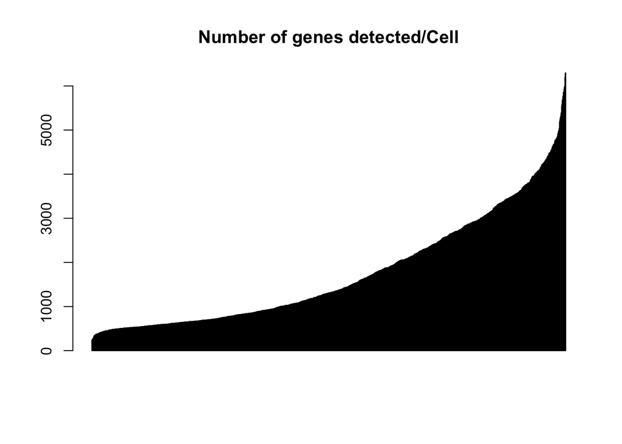

```r
barplot(sort(mydata$nFeature_RNA), main="Number of genes detected/Cell", names.arg = "")
```

```r
quantile(mydata$nFeature_RNA)
```

```
##     0%    25%    50%    75%   100%
##  235.0  705.0 1308.0 2588.5 6298.0
```

### Number of UMIs per cell

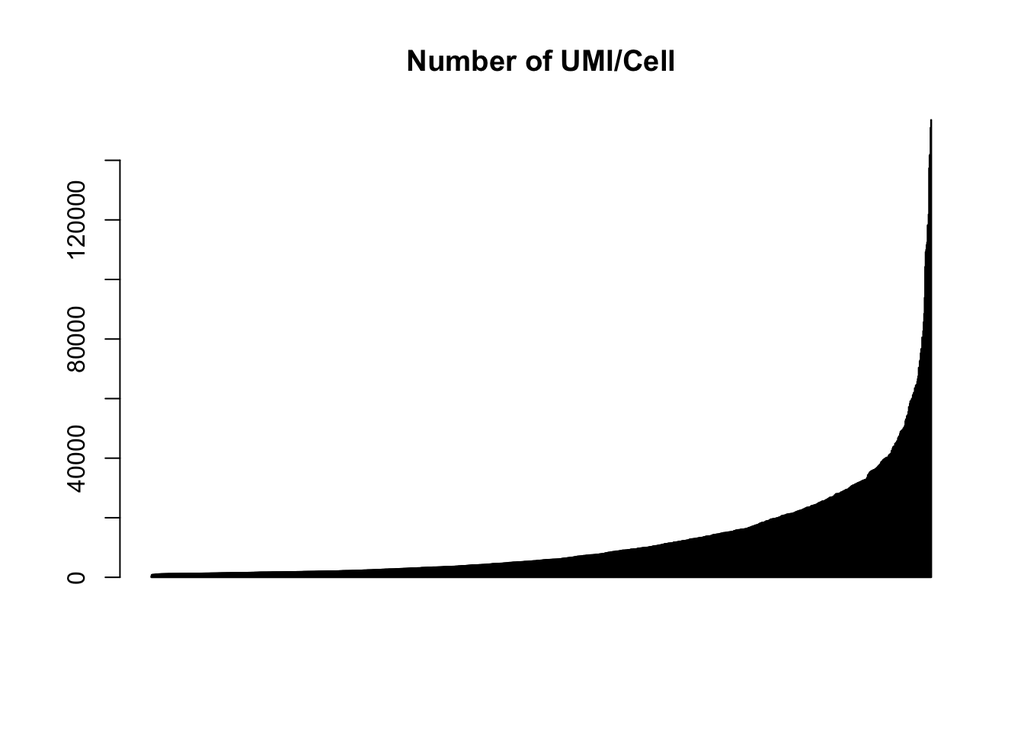

```r
barplot(sort(mydata$nCount_RNA), main="Number of UMI/Cell",names.arg = "")
```

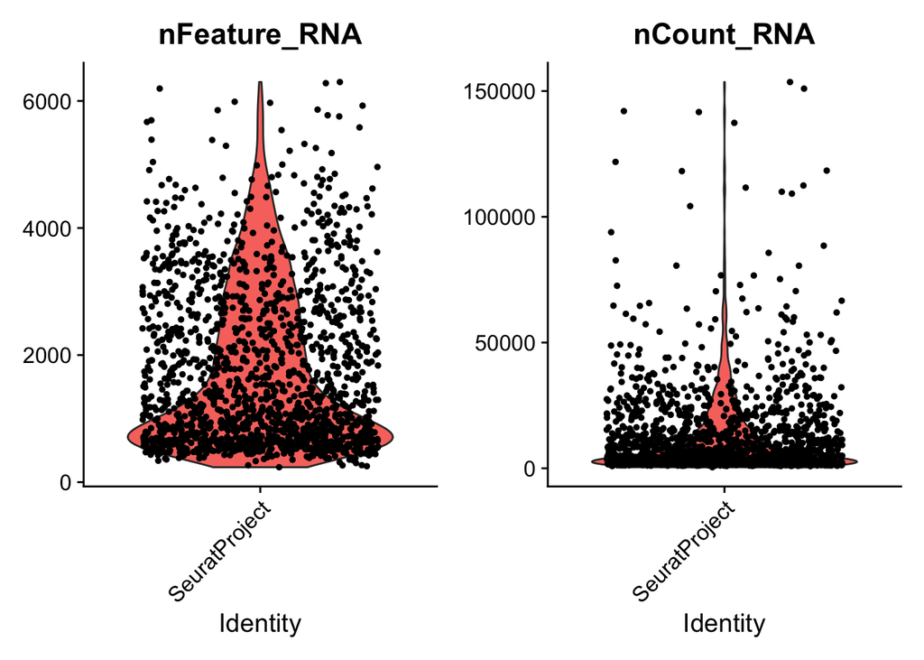

```r
VlnPlot(mydata, features = c("nFeature_RNA", "nCount_RNA"), ncol = 2)
```

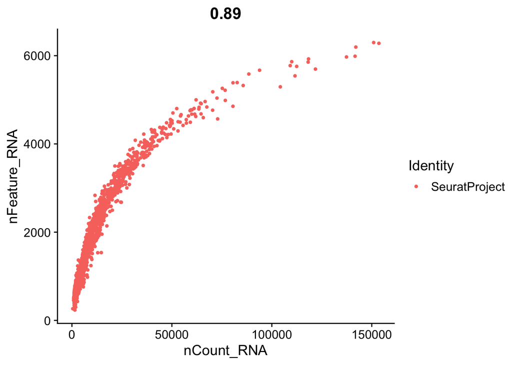

```r
FeatureScatter(mydata, feature1 = "nCount_RNA", feature2 = "nFeature_RNA")
```

Your aim while looking at these graphs is to define thresholds/cutoff that you will aply to filter cell out. Try to identify the cells that behave differently from the main population.

### Percentage of mitochondrial genes

To calculate the perentage of mitochonrial genes expressed in a cell, you must first provide a list of mitochondrial genes. In the paper, the authors did not provide their list. As a quick replacement, we will consider that mitochondrial genes are all the genes that starts with the pattern ‘mt:’. For a more refine analysis, you can use flybase or another source and carefully identify mitochondrial genes.

We then use the PercentageFeatureSet function, which calculates the percentage of counts originating from a set of features.

```r
mydata[["percent.mt"]] <- PercentageFeatureSet(mydata, pattern = "^mt:")

# Alternative : if you have a list of mitochondrial genes
#list = c("mTerf3","Mtpalpha" ,"mTTF")
#mydata[["percent.mt2"]] <- PercentageFeatureSet(mydata, features=list_mito )
```

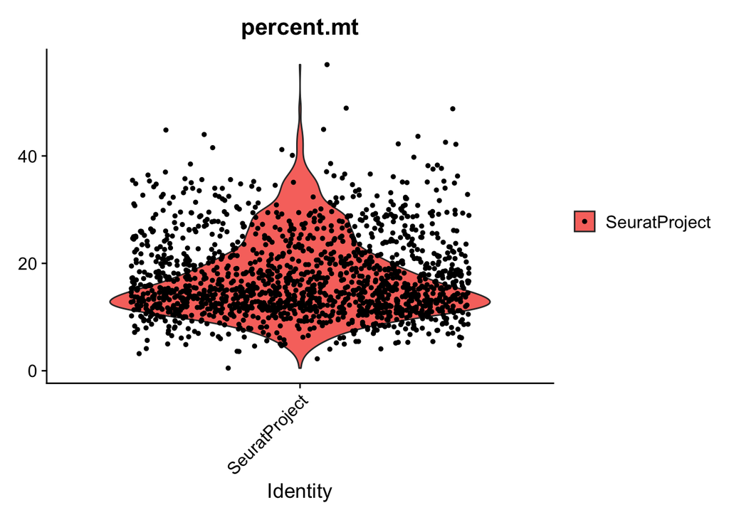

```r
VlnPlot(mydata, features = "percent.mt")
```

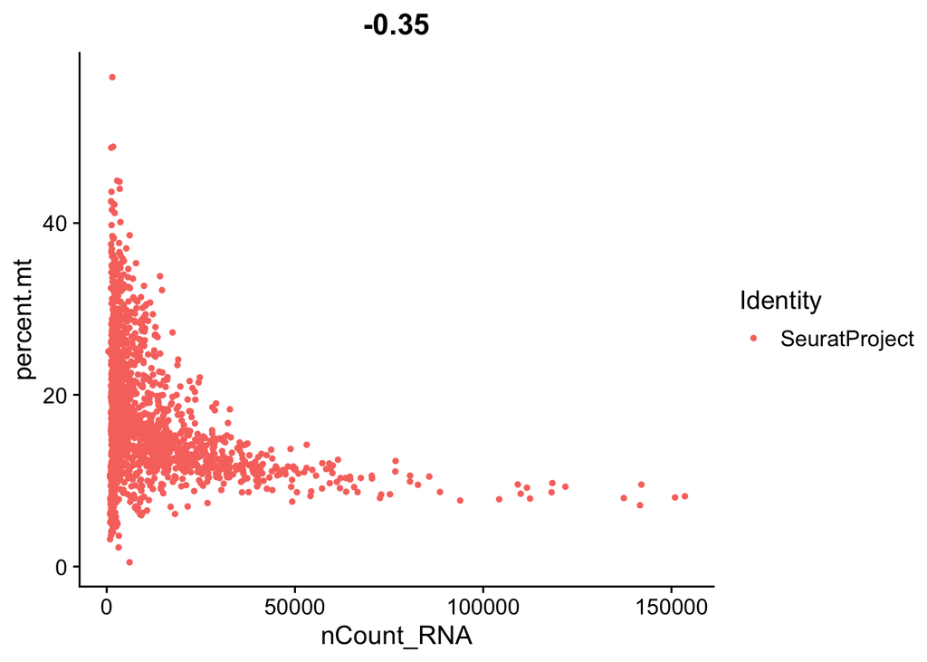

```r
FeatureScatter(mydata, feature1 = "nCount_RNA", feature2 = "percent.mt")
```

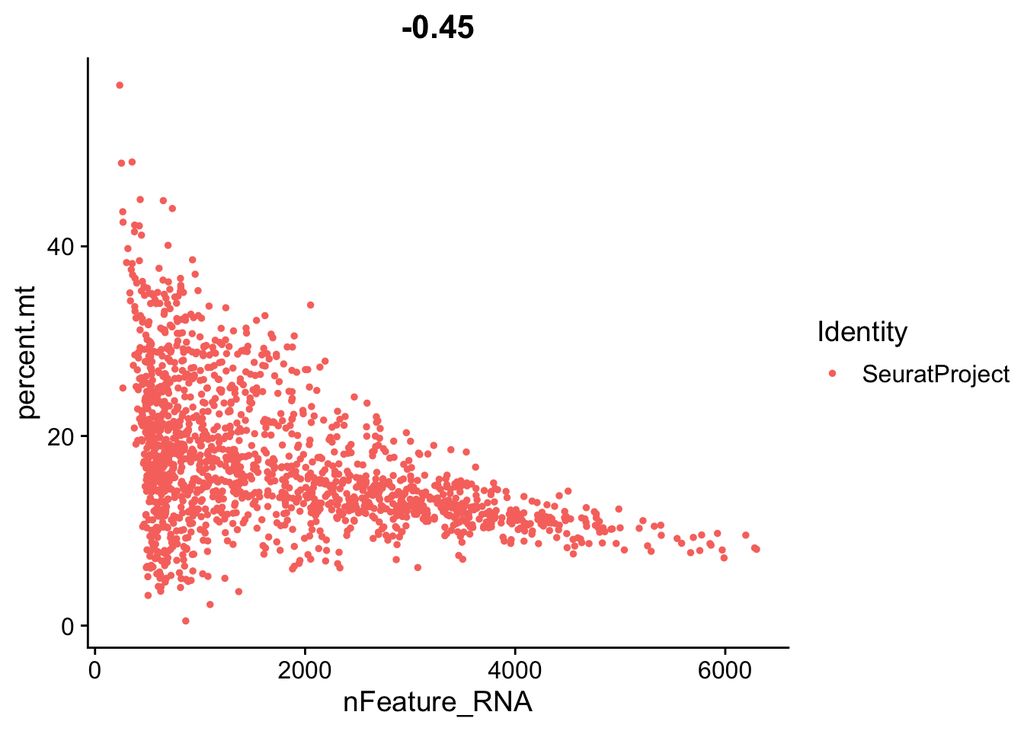

```r
FeatureScatter(mydata, feature1 = "nFeature_RNA", feature2 = "percent.mt")
```

### Group exercice on filtering

On of the most difficult parts of single cells pre-processing is to decide the threshold to define low and high quality cells. From the various graphs, decide the levels for low high quality cells dependant on the number of genes expressed per cell, the total UMIs per cell and the percentage of mitochonrial genes.

Discuss as a group.

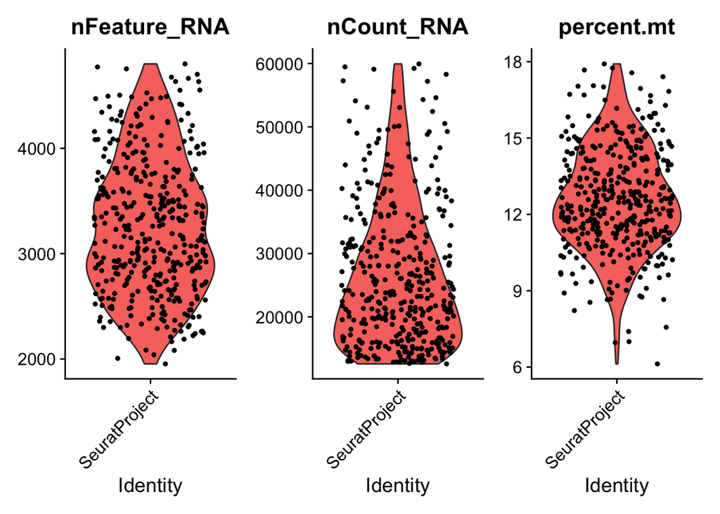

```r
# DEFINE THE CUTOFF VALUES AND VISUALIZE THE RESULTS
minGene    = 500
maxGene    = 5800
minUMI     = 12500
maxUMI     = 60000
maxpct_mt  = 18

# the function "subset" helps you to filter the cells
# we create a new seurat object containing the filtred cells
mydata_filtrd <- subset(mydata, subset = nFeature_RNA > minGene & nFeature_RNA < maxGene & nCount_RNA > minUMI  & nCount_RNA < maxUMI & percent.mt < maxpct_mt)

VlnPlot(mydata_filtrd, features = c("nFeature_RNA", "nCount_RNA", "percent.mt"), ncol = 3)
```

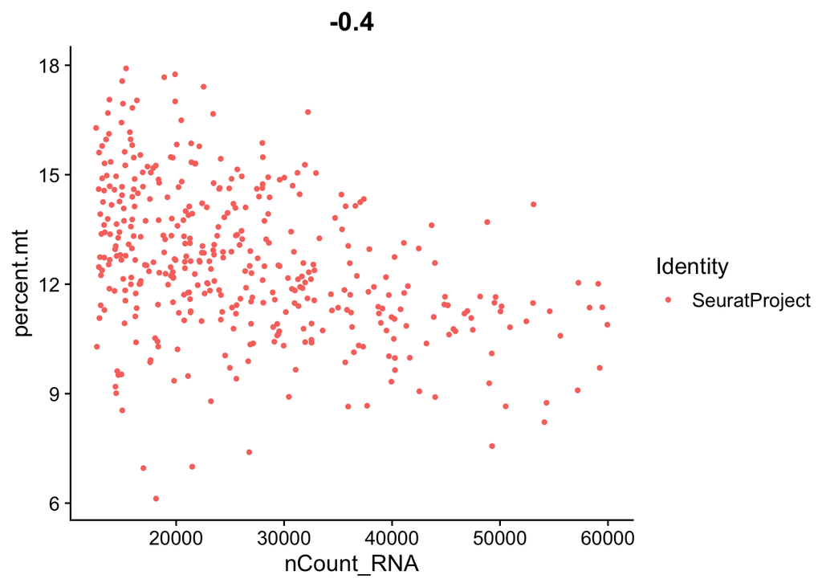

```r
FeatureScatter(mydata_filtrd, feature1 = "nCount_RNA", feature2 = "percent.mt")
```

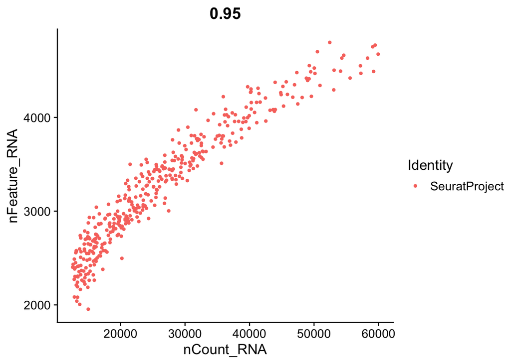

```r
FeatureScatter(mydata_filtrd, feature1 = "nCount_RNA", feature2 = "nFeature_RNA")
```

## Normalize the expression in cells

After removing unwanted cells from the dataset, the next step is to normalize the data. The objective is to correct for the sequencing bias.

As we noticed in the previous graphes, the cells do not have the same number of total UMI. This may be due biological differences (some cells express less RNA than other) but is likely to be the result of cell-specific sequencint biais (some cells have been less sequenced than other).

We are going to apply a global scaling method, which supposes that all cells are about the same RNA content. It aims to remove cell-specific systematic biases by scaling expression measures within each cell by a constant factor. We use a “LogNormalize” method that normalizes the feature expression measurements for each cell by the total expression, multiplies this by a scale factor (here the median total UMI per cell), and log-transforms the result.

```r
mydata_filtrd <- NormalizeData(mydata_filtrd, normalization.method = "LogNormalize", scale.factor = median(mydata_filtrd$nCount_RNA))
```

The resulting data are stored in the ‘data’ slot

Once you have pre-processed your data, you are ready for further analyses : identify sub-population of cells, pseudo-time analyses…

# Identify cell populations

In this section, we will analyse further the data and try to identify sub-populations of cells. The objective is to create clusters of cells, i.e to make group of cells that share similar expression profile. The mains steps are as follow :

- Select a subset of genes to perfom the downstream analyses
- Perform a dimension reduction
- Cluster the cells

## Select highly variables (hvg)

The downstream analyses (dimension reduction and then clustering) will se performed on the subset of genes. The aims is to exclude genes with minor biological relevance and decrease the computational load.

```r
# Find Variable Genes :
mydata_filtrd <- FindVariableFeatures(mydata_filtrd, selection.method = "vst", nfeatures = 2000,verbose = FALSE)

# Identify the 10 most highly variable genes
top10 <- head(VariableFeatures(mydata_filtrd), 10)
# you can also access the complete list using :
list_hvg = mydata_filtrd@assays$RNA@var.features
```

## Dimension Reduction

### Scaling

Expression of each gene is scaled (centered around its mean with a unit standard deviation). This step gives equal weight to all genes while performing the in the dimension reduction, and insure that the most expressed genes do not dominate.

```r
mydata_filtrd <- ScaleData(mydata_filtrd)
```

The scaled data are stored in the ‘scaled’ slot.

```r
mydata_filtrd <- RunPCA(mydata_filtrd, features = VariableFeatures(object = mydata_filtrd))
```

```
## PC_ 1
## Positive:  nos, spz, del, CG8507, stai, CG14545, Sesn, shu, CG17698, CG6287
##     CanB2, BigH1, pgc, 26-29-p, stil, PyK, Eno, CG7530, krimp, aret
##     CG17270, Taf12L, Cen, fabp, CG31689, Gapdh1, exu, CG17658, CG6967, CG9917
## Negative:  CG4440, CG10035, Bacc, CG13427, Df31, Tom, bl, fax, CG15628, BobA
##     hth, ed, CG5059, ci, tna, Gp150, sqd, sdt, l(3)neo38, N
##     Ppa, grh, vfl, Dl, roX1, wech, HmgD, CR43887, ASPP, Brd
## PC_ 2
## Positive:  twi, ventrally-expressed-protein-D, CG4500, Cyp310a1, sna, ltl, Ilp4, CG12177, CG16758, Mes2
##     stumps, if, htl, CG14688, CadN, zfh1, Mdr49, CG3036, Pka-C3, tin
##     sty, Asph, sprt, Inx3, CR45361, Mef2, Nplp2, be, Act87E, Ndae1
## Negative:  Lac, ASPP, Ptr, cno, grh, cv-2, aop, jbug, CG2162, btsz
##     sdt, crb, mew, Tom, fra, CG34383, 5-HT2A, CG34224, Doc1, CG45263
##     blot, hbs, Mipp1, ci, CG10176, pnr, wun2, dpp, bib, CG42788
## PC_ 3
## Positive:  CG8147, srp, ps, Lapsyn, fkh, peb, CG2930, hkb, Doc3, Oatp74D
##     CG15236, MRE23, exex, Gmap, Doc2, CG32053, Fas2, DNaseII, Ptx1, egr
##     CG31431, ImpE2, kek1, mspo, tup, Doc1, sas, ush, CG18754, Pdp1
## Negative:  dan, SoxN, sca, ths, CG6398, CG5059, bl, lea, ImpL2, Imp
##     Pino, rdx, neur, RnrS, Meltrin, sbb, brk, Shroom, noc, pyr
##     mid, sog, danr, Toll-6, wb, slp1, lok, pico, Atg18a, path
## PC_ 4
## Positive:  aay, apt, Cys, sog, CG2930, phyl, mnd, fkh, CG32053, bib
##     MRE23, DNaseII, brk, pDsRed, RpL10Ab, Gmap, ps, CG8654, Sox21a, CG18754
##     a, CG13427, CG31431, Lac, SoxN, exex, Pdp1, Ocho, vnd, Obp99a
## Negative:  net, Ama, Nrt, CrebA, CycE, emc, mirr, zfh1, rst, chrb
##     dap, how, pAbp, Alk, hbs, Glut4EF, CG45263, wake, kay, SNCF
##     Dtg, CG14427, zen, spen, if, CadN, chn, ptc, vfl, shep
## PC_ 5
## Positive:  SNCF, zen, zen2, Ama, C15, Z600, CG13653, rho, net, kay
##     Alk, CG8960, opa, alphagamma-element:CR32865, CG14111, Dtg, CG13454, CG13654, wntD, toc
##     Ance, rst, ush, dap, Ect4, CG14915, CR44953, egr, Doc3, E(spl)m5-HLH
## Negative:  dm, Bsg, Tet, spoon, Dl, CG12535, Trf2, CG9821, mt:CoI, apt
##     sm, Hrb27C, pAbp, Ssdp, CG34380, mt:ND1, Oatp74D, fs(1)h, Smr, roX1
##     sqd, pum, msi, CR45874, CG45050, CG11138, AGO1, CG43736, east, RapGAP1
```

It is worth analysing the genes that contribute the most to each axes. It may help you to identify genes whose expression decrease/increase together. The DimHeatmap function in Seurat helps you to visualise the genes that are driving the components and allows to get some insight about the heterogeneity of the data.

```r
# Examine and visualize PCA results :
print(mydata_filtrd[["pca"]], dims = 1:5, nfeatures = 5)
```

```
## PC_ 1
## Positive:  nos, spz, del, CG8507, stai
## Negative:  CG4440, CG10035, Bacc, CG13427, Df31
## PC_ 2
## Positive:  twi, ventrally-expressed-protein-D, CG4500, Cyp310a1, sna
## Negative:  Lac, ASPP, Ptr, cno, grh
## PC_ 3
## Positive:  CG8147, srp, ps, Lapsyn, fkh
## Negative:  dan, SoxN, sca, ths, CG6398
## PC_ 4
## Positive:  aay, apt, Cys, sog, CG2930
## Negative:  net, Ama, Nrt, CrebA, CycE
## PC_ 5
## Positive:  SNCF, zen, zen2, Ama, C15
## Negative:  dm, Bsg, Tet, spoon, Dl
```

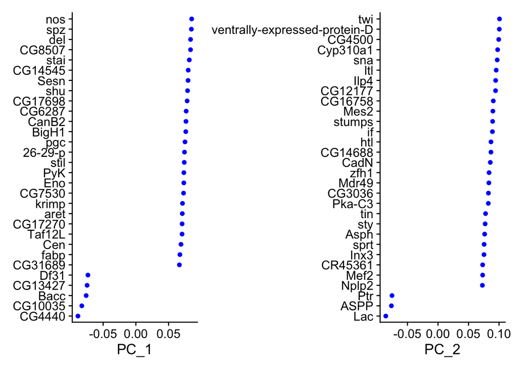

```r
VizDimLoadings(mydata_filtrd, dims = 1:2, reduction = "pca")
```

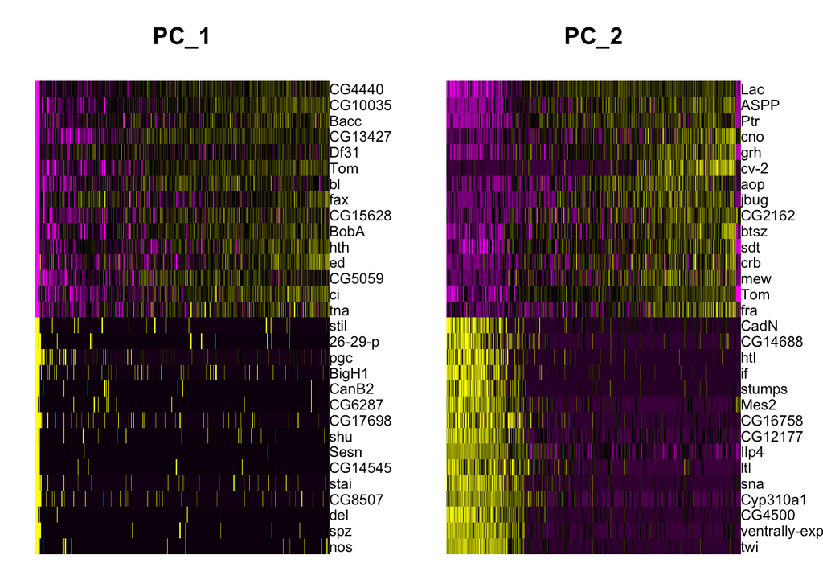

```r
# Plot expression of gene driving principal component
DimHeatmap(mydata_filtrd, dims = 1:2)
```

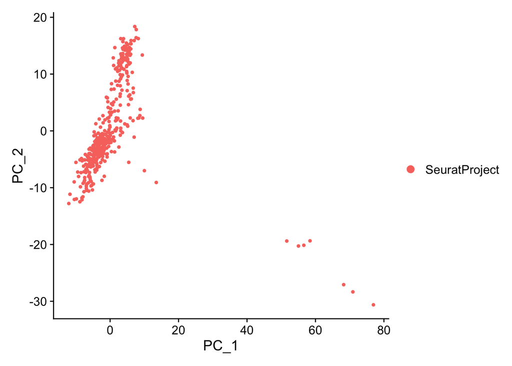

```r
library(ggplot2)
DimPlot(mydata_filtrd, reduction = "pca")
```

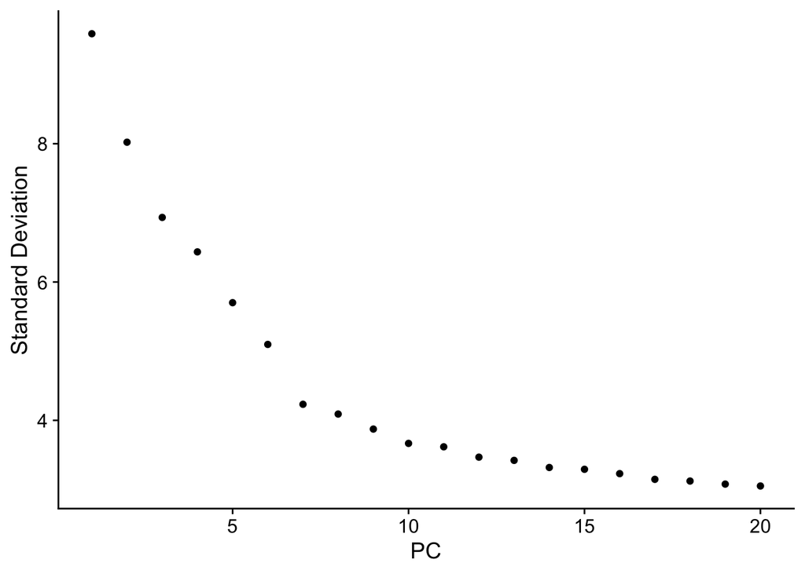

```r
ElbowPlot(mydata_filtrd)
```

## Cluster cells

There are two main steps

```r
nPC = 20
mydata_filtrd <- FindNeighbors(mydata_filtrd, dims = 1:nPC)
mydata_filtrd <- FindClusters(mydata_filtrd, resolution = 0.5)
```

```
## Modularity Optimizer version 1.3.0 by Ludo Waltman and Nees Jan van Eck
##
## Number of nodes: 399
## Number of edges: 13134
##
## Running Louvain algorithm...
## Maximum modularity in 10 random starts: 0.7527
## Number of communities: 4
## Elapsed time: 0 seconds
```

Usually the clustering are presented using UMAP which visually separates the group more nicely than PCA.

```r
# If you haven't installed UMAP, you can do so via reticulate::py_install(packages =
# 'umap-learn')
mydata_filtrd <- RunUMAP(mydata_filtrd, dims = 1:nPC)
```

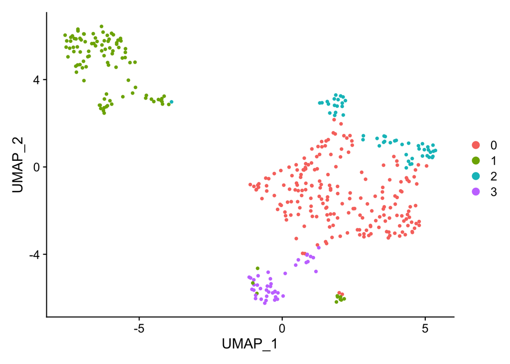

```r
DimPlot(mydata_filtrd, reduction = "umap")
```

```r
# find all markers of cluster 1
cluster1.markers <- FindMarkers(mydata_filtrd, ident.1 = 1, min.pct = 0.25)
```

[output not shown]

```r
head(cluster1.markers, n = 5)
```

```
##               p_val avg_logFC pct.1 pct.2    p_val_adj
## Mes2   2.061866e-55  1.730477 0.981 0.263 2.579600e-51
## sna    3.214489e-53  1.895653 0.896 0.167 4.021647e-49
## stumps 4.874307e-53  1.480829 0.802 0.068 6.098245e-49
## twi    1.799197e-52  2.216349 0.915 0.225 2.250976e-48
## CG4500 7.672782e-51  2.151045 0.915 0.208 9.599418e-47
```

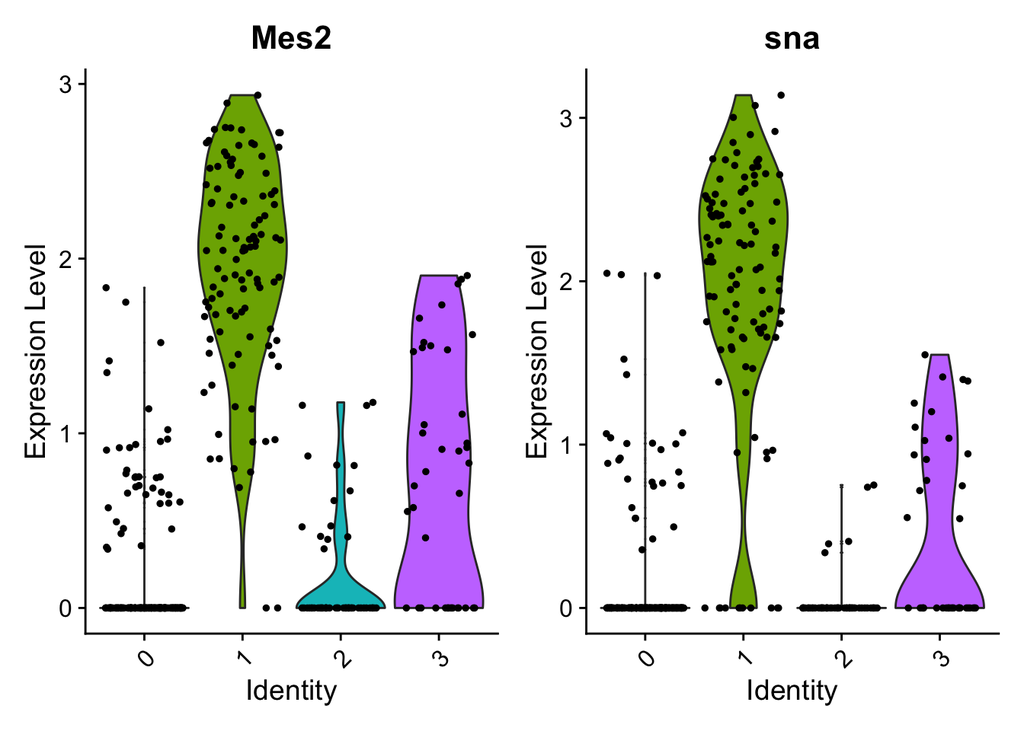

```r
VlnPlot(mydata_filtrd, features = c("Mes2", "sna"))
```